# Probabilidad

Dayra Torres

2025-09-15

# PROBABILIDAD

La probabilidad es una rama de las matemáticas que estudia y mide la posibilidad de que ocurra un evento aleatorio, expresada como un número entre 0 y 1. Se calcula como la razón entre el número de casos favorables y el número total de casos posibles, y se aplica en campos como la estadística, la economía y la física para predecir la frecuencia de sucesos futuros.

. Es una medida de la certidumbre de que un evento sucederá. . Un valor de 0 indica un evento imposible, mientras que un valor de 1 indica un evento seguro. . Se utiliza para analizar fenómenos con resultados inciertos.

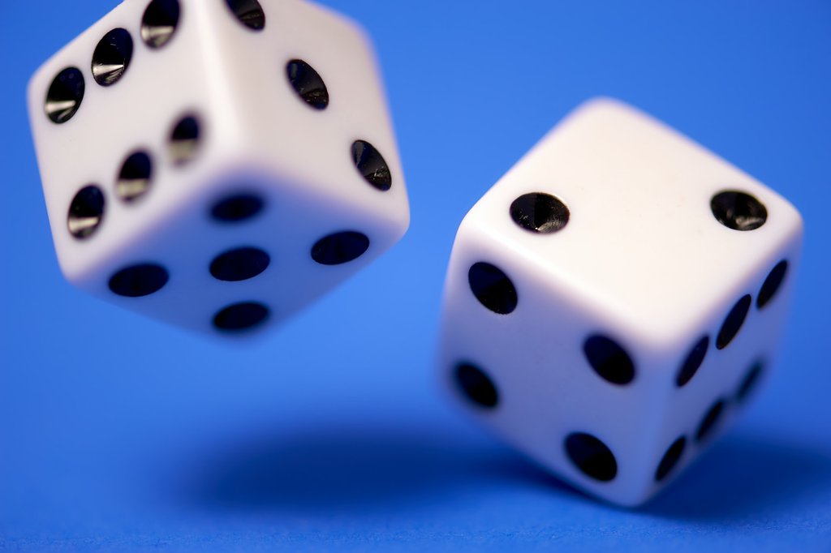

probabilidad

# INTRODUCCION

La probabilidad es una rama de las matemáticas que se ocupa de estudiar la incertidumbre y la aleatoriedad, asignando un valor numérico a la posibilidad de que ocurra un evento. Se expresa como un número entre 0 y 1, donde 0 significa que el evento es imposible y 1 que es seguro. Se utiliza para analizar eventos cuyos resultados no se pueden predecir con certeza, como lanzar una moneda o un dado, y es fundamental para la toma de decisiones en muchas áreas como la estadística, la economía y la ciencia de datos.

Conceptos Clave Fenómeno Aleatorio: Un proceso que, bajo las mismas condiciones, puede producir diferentes resultados. Experimento Aleatorio: La repetición de un fenómeno aleatorio. Resultado: Cada uno de los posibles outcomes de un experimento aleatorio. Suceso o Evento: Un conjunto de uno o más resultados de un experimento aleatorio. Espacio Muestral: El conjunto de todos los posibles resultados de un experimento aleatorio, denotado por $\Omega$ (Omega).

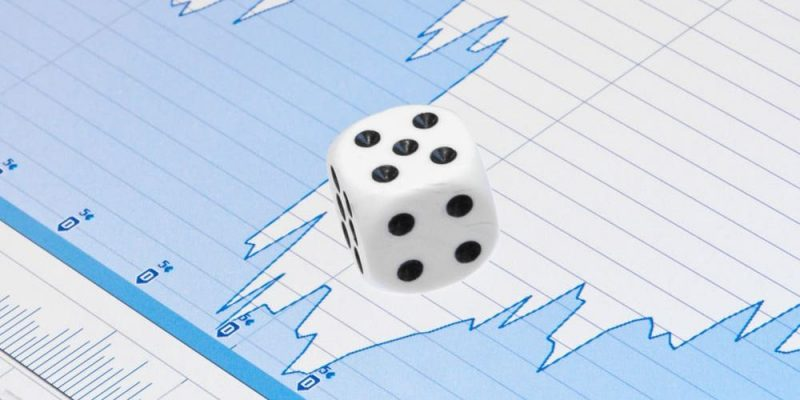

introduccion

# FENOMENO ALEATORIO

Un fenómeno aleatorio en probabilidad es cualquier proceso cuyo resultado no puede predecirse con certeza, incluso bajo el mismo conjunto de condiciones. Se caracteriza por la variabilidad e incertidumbre de sus resultados, lo que significa que al repetirlo, se pueden obtener resultados diferentes cada vez.

Ejemplos comunes son lanzar un dado o una moneda, donde el resultado no es predecible. Características principales de un fenómeno aleatorio . Incertidumbre: El resultado no se puede conocer de antemano con total seguridad. . Variabilidad: Los resultados pueden ser diferentes cada vez que se realiza el experimento. . Regularidad estadística: Aunque los resultados individuales son inciertos, al repetir el experimento muchas veces, los resultados globales tienden a estabilizarse, formando una regularidad que se puede cuantificar con la probabilidad.

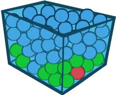

fenomeno aleatorio

# ESPACIO MUESTRAL

El espacio muestral (denotado como E, S o Ω) en probabilidad es el conjunto de todos los resultados posibles de un experimento aleatorio. Es decir, es la lista completa de todas las cosas que pueden suceder cuando se realiza una acción al azar, como lanzar un dado o una moneda.

Ejemplos para entenderlo mejor: Al lanzar una moneda: El espacio muestral es {cara, cruz}. Al lanzar un dado de seis caras: El espacio muestral es {1, 2, 3, 4, 5, 6}. Al elegir el tipo de número (par o impar) al lanzar un dado: El espacio muestral sería {par, impar} Características importantes: Notación: Se escribe entre llaves { } y se usa la letra S o Ω para representarlo. Fundamental para la probabilidad: El espacio muestral es la base para calcular la probabilidad de cualquier evento. Sin él, no se puede saber la posibilidad de que ocurra algo específico. Finito o infinito: Puede contener un número limitado de resultados (como en los ejemplos anteriores) o un número infinito de ellos, dependiendo del experimento.

[figure not shown]

espacio muestral

# EVENTO

En probabilidad, un evento es una colección de uno o más resultados posibles de un experimento aleatorio. Es decir, es un subconjunto del espacio muestral (el conjunto de todos los resultados posibles) que representa un suceso o resultado particular de interés. Por ejemplo, al lanzar un dado, el evento “obtener un número par” consiste en los resultados {2, 4, 6}.

Ejemplos de eventos: . Al lanzar un dado: Evento: Obtener un número par {2, 4, 6}. Evento: Obtener un número primo {2, 3, 5}. . Al lanzar una moneda: Evento: Obtener cara. Evento: Obtener cruz. . Al sacar una carta de una baraja: Evento: Sacar un as. Características clave de un evento: . Subconjunto del espacio muestral: Un evento siempre está formado por elementos que se encuentran dentro del espacio muestral. . Resultado de un experimento: Es aquello que puede ocurrir o no ocurrir cuando se realiza un experimento aleatorio. . Probabilidad: La probabilidad de un evento, que se puede expresar como P(E), es un valor que oscila entre 0 (evento imposible) y 1 (evento seguro).

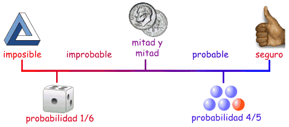

evento

# TEOREMAS

. Teorema de la Probabilidad Total: Propósito: Permite calcular la probabilidad de un evento A que puede ocurrir a través de diferentes “caminos” o particiones del espacio muestral. Cómo funciona: Se descompone la probabilidad de un evento en la suma de las probabilidades condicionadas de ese evento, multiplicadas por la probabilidad de cada partición. Fórmula general: Si un evento A puede ocurrir a través de una partición {B₁, B₂, …, Bₙ} del espacio muestral (es decir, las Bᵢ son mutuamente excluyentes y cubren todas las posibilidades), entonces $P(A) = \sum P(A|Bᵢ) * P(Bᵢ)$.

. Teorema de Bayes: Propósito: Mide cómo cambia la probabilidad de un evento a la luz de nueva información (evidencia). Cómo funciona: Permite calcular la probabilidad de un evento anterior (suceso a priori) dado un suceso posterior (la evidencia). Fórmula: P(A|B) = [P(B|A) * P(A)] / P(B), donde P(A|B) es la probabilidad de A dado B, y P(B) puede calcularse usando el Teorema de la Probabilidad TotaL.

. Regla de la Suma de Probabilidades: Propósito: Calcula la probabilidad de que ocurra uno de dos eventos (o ambos). Fórmula: Para dos eventos $A$ y $B$, $P(A∪B) = P(A) + P(B) - P(A ∩ B)$, donde $P(A ∩ B)$ es la probabilidad de que ambos eventos ocurran simultáneamente.

. Regla de la Multiplicación de Probabilidades: Propósito: Calcula la probabilidad de que dos eventos ocurran juntos (intersección de eventos). Fórmula: $P(A y B) = P(A) * P(B|A)$, donde $P(B|A)$ es la probabilidad de B dado que A ya ha ocurrido. Si los eventos son independientes, entonces $P(A \text{ y} B) = P(A) * P(B)$.

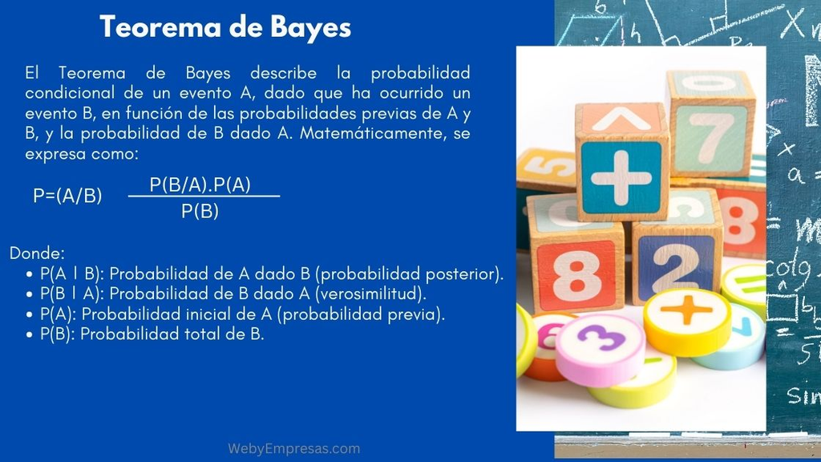

teorema

# CONCLUSIONES

Las conclusiones sobre probabilidad implican que esta rama matemática sirve para cuantificar la posibilidad de ocurrencia de eventos en fenómenos aleatorios, proporcionando un marco para la toma de decisiones, la predicción y la comprensión de la incertidumbre. Se puede concluir que la probabilidad se expresa como un valor entre 0 (imposible) y 1 (seguro), y es esencial para el análisis de datos, la ciencia y muchas aplicaciones prácticas. En resumen: Las conclusiones sobre probabilidad destacan su papel como herramienta fundamental para interpretar el azar y la incertidumbre, facilitando la toma de decisiones informadas y el análisis de fenómenos en diversas áreas del conocimiento y la vida diaria.

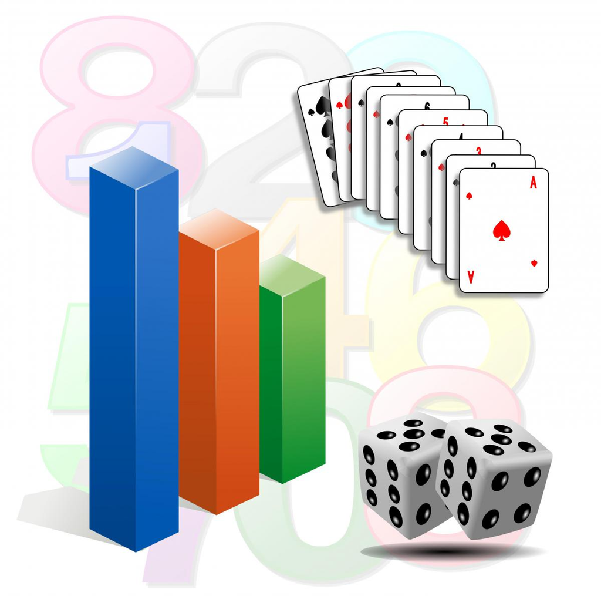

conclusiones